# Veri Madenciligi Final Odevi

Tarik Celik 121516062

2021-01-24

# 1. DECISION TREE & LOGISTIC REGRESSION

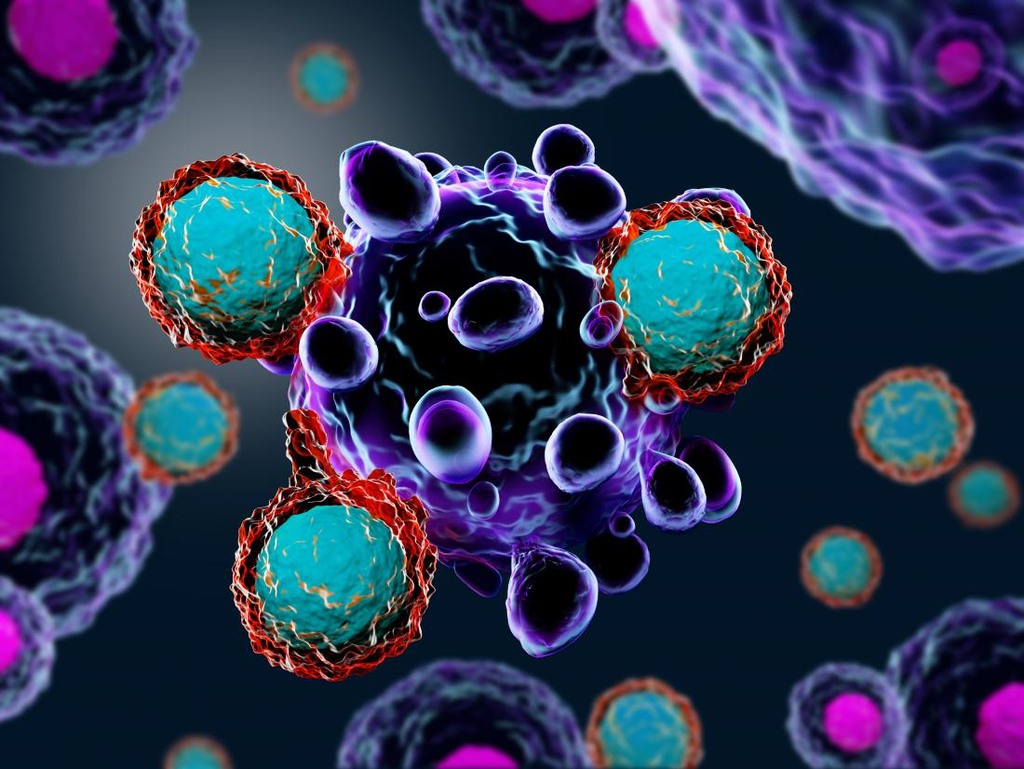

```r
breast=read.csv("C:/Users/Tarık/Desktop/breast.cancer.csv")
```

**Breast verisi gogus kanseri hucresinin ozelliklerini belirten bir veridir. Asagida degiskenler tanimlanmistir.**

- *diagnosis: M=Kotu Huylu, B=Iyi Huylu*
- *radius: Merkezden cevre uzerindeki noktalara olan mesafeler*
- *texture: Gri tonlama degerlerinin standart sapmasi*
- *perimeter: Hucrenin cevresi*
- *area: Hucrenin alani*
- *smoothness: Yaricap uzunluklarinda yerel degisim*
- *compactness: Cevre ^ 2 / Alan - 1.0*
- *concavity: Konturun icbukey kisimlarinin ciddiyeti*
- *concave points: Konturun icbukey kisimlarinin sayisi*
- *symmetry: Simetri*

*Kaynak: https://www.kaggle.com/shankarat/breast-cancer*

- **Veri degiskenlerin standart sapmasi ve ortalamalari ile ikiye bolunmus durumdadir. Ortalama ile ilgilenmek istedigim icin ilgili degiskenleri secerek veriyi tekrar duzenledim. Ayni zamanda agac grafiklerinin karismamasi icin degisken isimlerini kisalttim. Son hali head komutuyla gozukmektedir.**

```r
breast=select(breast, diagnosis:symmetry_mean)
     names(breast) <- c("diagnosis","radius","texture","perimeter","area","smoothness","compactness","concavity","concave.p","symmetry")
     head(breast)
```

```
##   diagnosis radius texture perimeter   area smoothness compactness concavity
     ## 1         M  17.99   10.38    122.80 1001.0    0.11840     0.27760    0.3001
     ## 2         M  20.57   17.77    132.90 1326.0    0.08474     0.07864    0.0869
     ## 3         M  19.69   21.25    130.00 1203.0    0.10960     0.15990    0.1974
     ## 4         M  11.42   20.38     77.58  386.1    0.14250     0.28390    0.2414
     ## 5         M  20.29   14.34    135.10 1297.0    0.10030     0.13280    0.1980
     ## 6         M  12.45   15.70     82.57  477.1    0.12780     0.17000    0.1578
     ##   concave.p symmetry
     ## 1   0.14710   0.2419
     ## 2   0.07017   0.1812
     ## 3   0.12790   0.2069
     ## 4   0.10520   0.2597
     ## 5   0.10430   0.1809
     ## 6   0.08089   0.2087
```

```r
apply(breast,2,function(x) sum(is.na(x)))
```

```
##   diagnosis      radius     texture   perimeter        area  smoothness
     ##           0           0           0           0           0           0
     ## compactness   concavity   concave.p    symmetry
     ##           0           0           0           0
```

- **Eksik gozlem kontrolu yapildi. Sonuca gore veride eksik gozlem olmadigini goruyoruz.**

## TRAIN VE TEST DATASI

```r
set.seed(101)
     sample=sample.int(n=nrow(breast), size=floor(.75*nrow(breast)), replace=F)
     train=breast[sample, ]
     test=breast[-sample, ]
```

- **Verinin %75’ini rastgele orneklem olarak cekip train olusturuyoruz. Geri kalanlar test olarak adlandirildi.**

# DECISION TREES AND PRUNING

## Decision Trees

```r
set.seed(101)
     tree.model1=tree(diagnosis~., data=train)
     summary(tree.model1)
```

```
##
     ## Classification tree:
     ## tree(formula = diagnosis ~ ., data = train)
     ## Variables actually used in tree construction:
     ## [1] "concave.p"   "area"        "compactness" "texture"     "perimeter"
     ## [6] "concavity"   "smoothness"
     ## Number of terminal nodes:  12
     ## Residual mean deviance:  0.1763 = 72.99 / 414
     ## Misclassification error rate: 0.03756 = 16 / 426
```

**Modelin sonucunda terminal nod, deviance olcutu degeri ve yanlis siniflandirma oranini gorebiliyoruz. Plot cizdirerek agacin yapisina bakalim.**

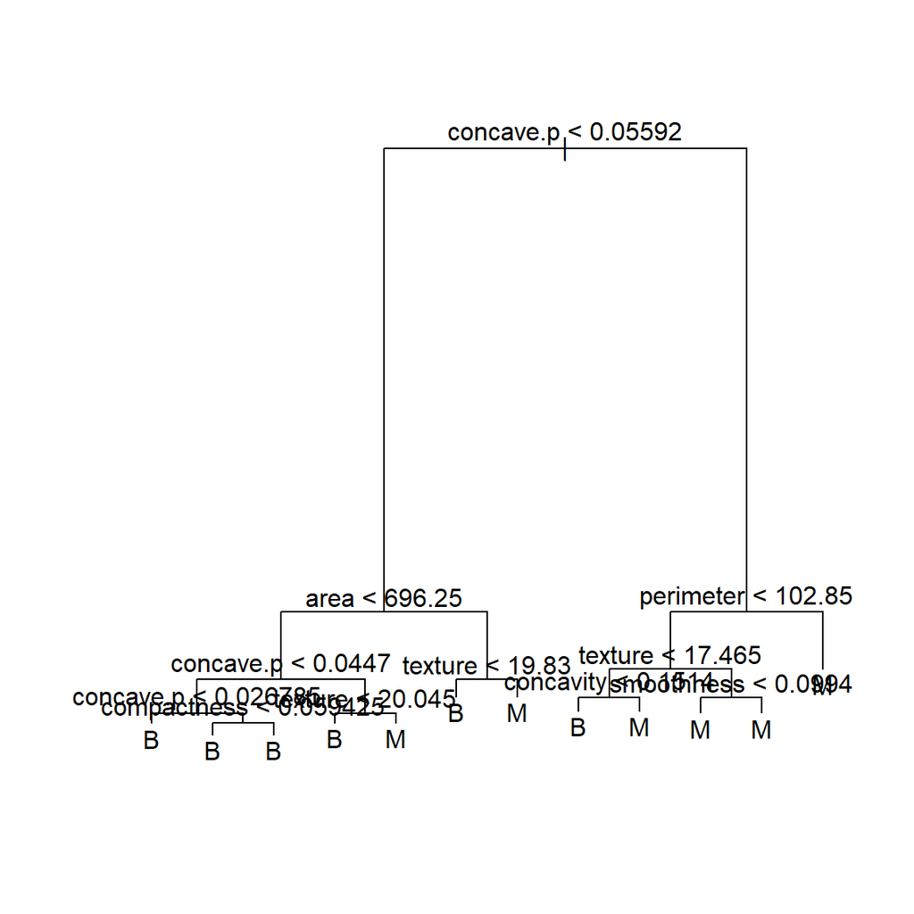

```r
plot(tree.model1);text(tree.model1,pretty=0)
```

- **Buyuk ve karmasik bir agac plotu ciktisi aldik. Bunun accuracy, sensitivity gibi degerlerine bakmak kesin sonucu verecektir.**
- **Bu degerlere bakmak icin en iyi yontem confusion matrix cizdirmektir.**

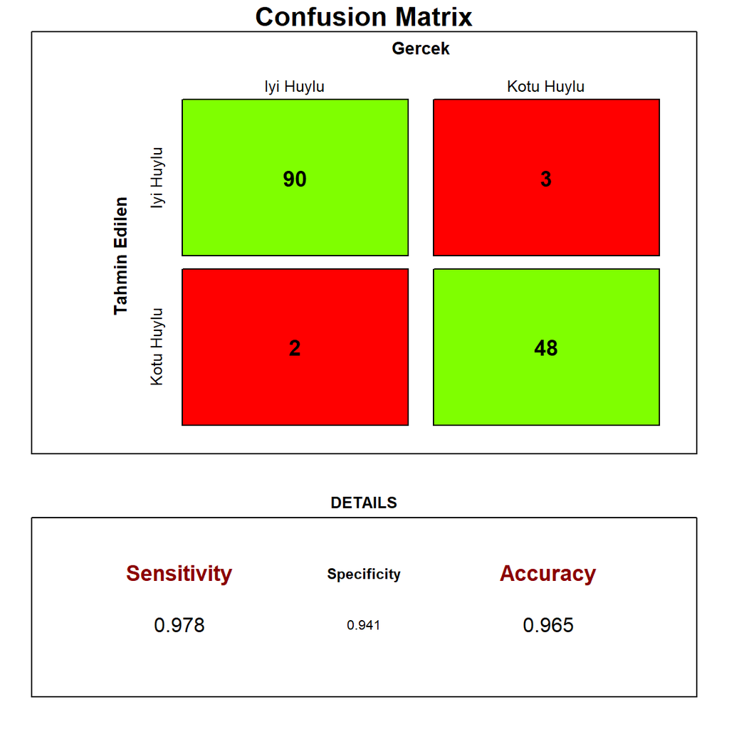

**Confusion matrixe baktigimiz zaman modelin test seti uzerinde %96.5 dogruluk orani (accuracy) oldugunu goruyoruz. Bu oran gercekten cok yuksek ve iyi calistigini bize gostermis oluyor. Simdi budama yaparak tahmin varyansini dusurecegiz ve nasil bir dogruluk orani verecegine bakacagiz.**

## Pruning

**Optimal α degerini belirlemek icin cross validation kullanacagiz. Buldugumuz deger ile modeli tekrar kurup degerleri inceleyecegiz.**

```r
set.seed(101)
     tree.model2=cv.tree(tree.model1, FUN=prune.misclass)
     tree.model2
```

```
## $size
     ## [1] 12  9  7  5  3  2  1
     ##
     ## $dev
     ## [1]  39  38  39  45  45  44 161
     ##
     ## $k
     ## [1]  -Inf   0.0   1.0   3.0   3.5   6.0 124.0
     ##
     ## $method
     ## [1] "misclass"
     ##
     ## attr(,"class")
     ## [1] "prune"         "tree.sequence"
```

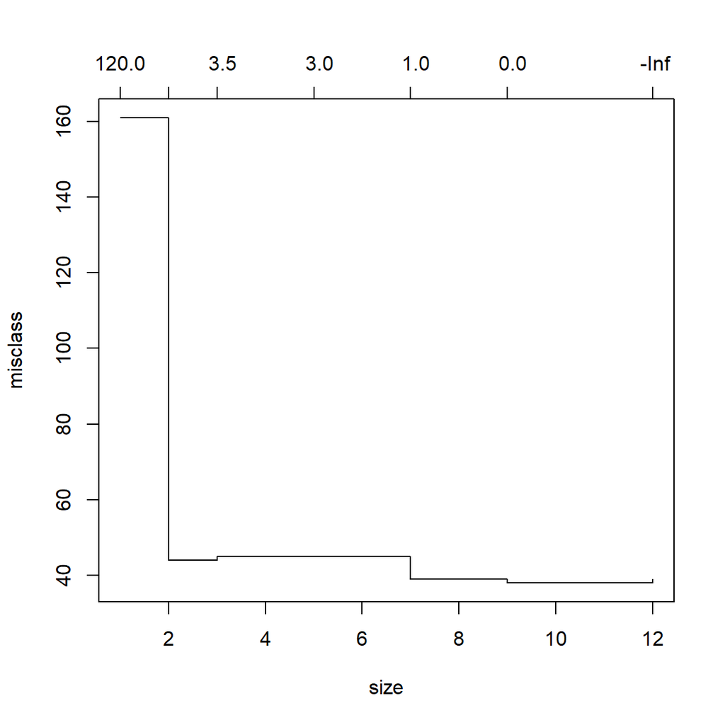

```r
plot(tree.model2)
```

**Grafige baktigimizda en iyi deger 9 gibi duruyor. Ancak diger degerler denendiginde goruldu ki 8’de ayni accuracy oranini veriyor. Bu yuzden 8 degerini kullanmak en mantikli secim olacaktir.**

```r
set.seed(12345)
     tree.model2=prune.misclass(tree.model1,best=8)
```

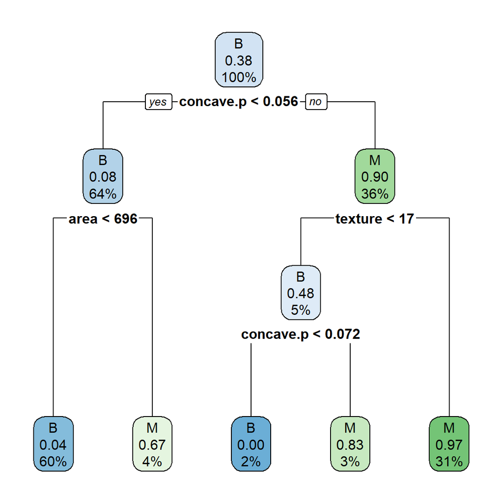

```r
fit <- rpart(diagnosis~., data = train, method = 'class')
     rpart.plot(fit, extra = 106)
```

```r
summary(tree.model2)
```

```
##
     ## Classification tree:
     ## snip.tree(tree = tree.model1, nodes = c(8L, 13L))
     ## Variables actually used in tree construction:
     ## [1] "concave.p" "area"      "texture"   "perimeter" "concavity"
     ## Number of terminal nodes:  9
     ## Residual mean deviance:  0.2348 = 97.93 / 417
     ## Misclassification error rate: 0.03756 = 16 / 426
```

**Ilk plot gibi karisik olmayan bir agac yapisiyla karsilastik. Simdi tahmin performansini inceleyelim.**

```r
tahmin=predict(tree.model2,test,type="class")
```

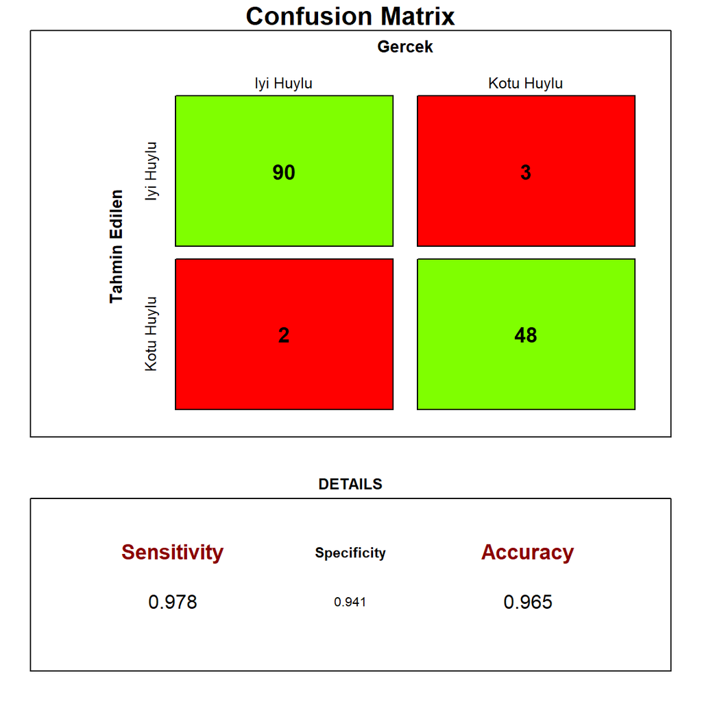

**Yorumlanmasi daha kolay bir agac elde etmis olsak bile dogruluk oraninda bir degisim olmadigini gorduk. Tekrardan %96.5 accuracy degerine sahibiz.**

## MODEL KIYASLAMA

| MODEL | ACCURACY ORANI | SENSITIVITY |
| --- | --- | --- |
| Decision Trees | 0.965 | 0.978 |
| Pruning Decision Trees | 0.965 | 0.978 |

**Goruldugu uzere iki modelin de accuracy ve sensitivity degerleri tamamen esittir. Budama yapmak dogruluk oranimizi arttirmadi ama yorumlanmasi daha kolay bir agac elde etmis olduk.**

# BAGGING

## 500 Bootstrap Sample

**Karar agaclarinda ki yuksek varyans problemini cozmek icin bagging yapacagiz.**

**Train set uzerinde bagging modelimizi kuracagiz.**

- *mtray=Degisken Sayisi (p)*
- *Default sample sayisi 500.*

```r
set.seed(101)
     Bagging.model1=randomForest(diagnosis~., data=train, mtry=9, importance=TRUE)
     Bagging.model1
```

```
##
     ## Call:
     ##  randomForest(formula = diagnosis ~ ., data = train, mtry = 9,      importance = TRUE)
     ##                Type of random forest: classification
     ##                      Number of trees: 500
     ## No. of variables tried at each split: 9
     ##
     ##         OOB estimate of  error rate: 7.04%
     ## Confusion matrix:
     ##     B   M class.error
     ## B 251  14  0.05283019
     ## M  16 145  0.09937888
```

- **Degiskenlerin accuracy ve gini olcutlerine gore onemlilikleri verilmistir.**

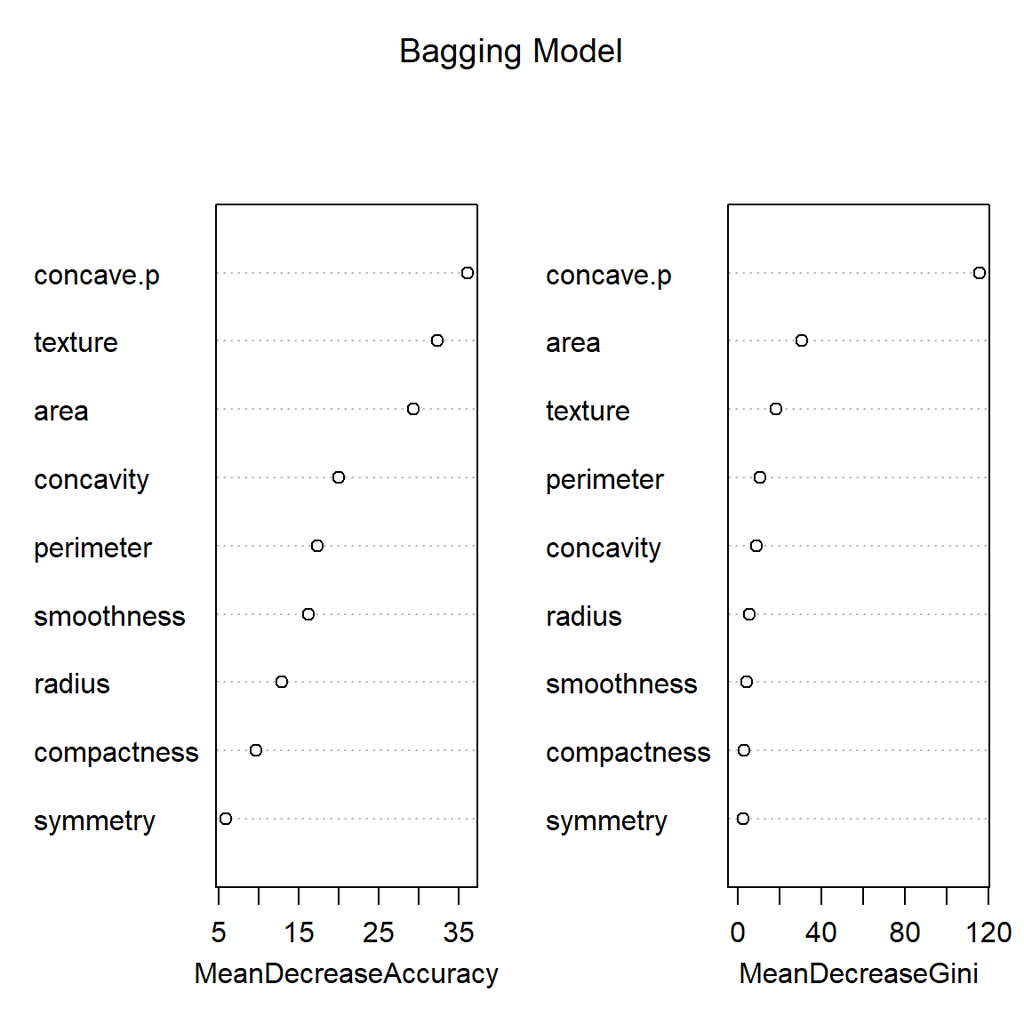

```r
varImpPlot(Bagging.model1, main = "Bagging Model")
```

- **Concave point degiskeni 2 grafikte de en onemli degisken olarak gozukuyor.**

**Modelin tahmin performansini inceleyelim.**

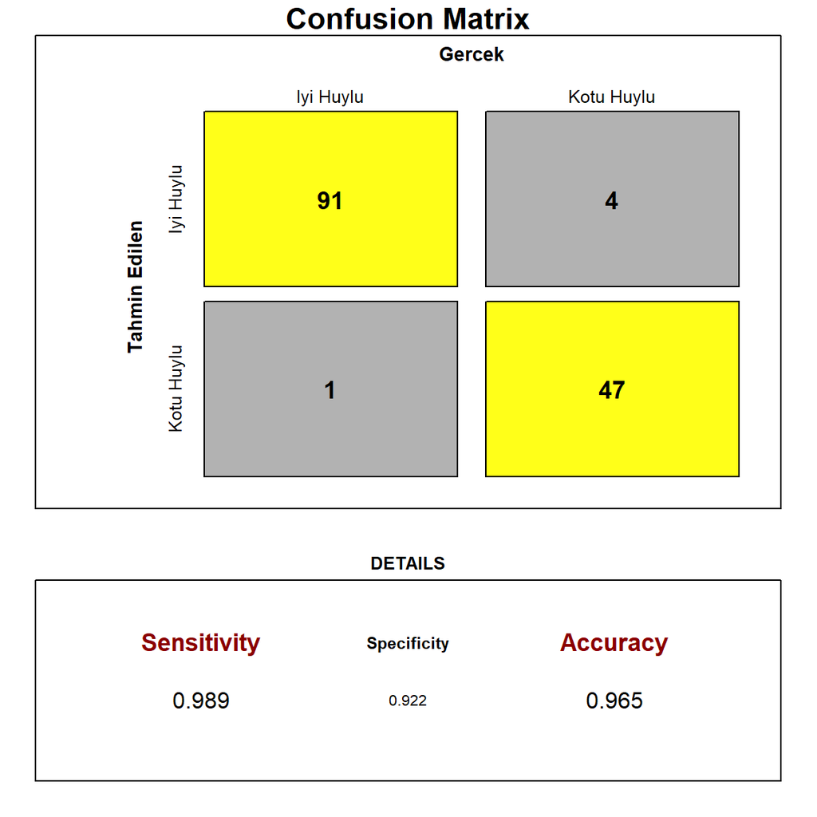

- **Yeniden %96.5 dogruluk orani elde ettik. Ancak bu sefer sensitivity degerinde artis var.**

**Default sample sayisi disinda bir deger belirlemek icin asagidaki grafige bakabiliriz. Daha iyi bir sonuc alip alamayacagimizi incelemis olacagiz.**

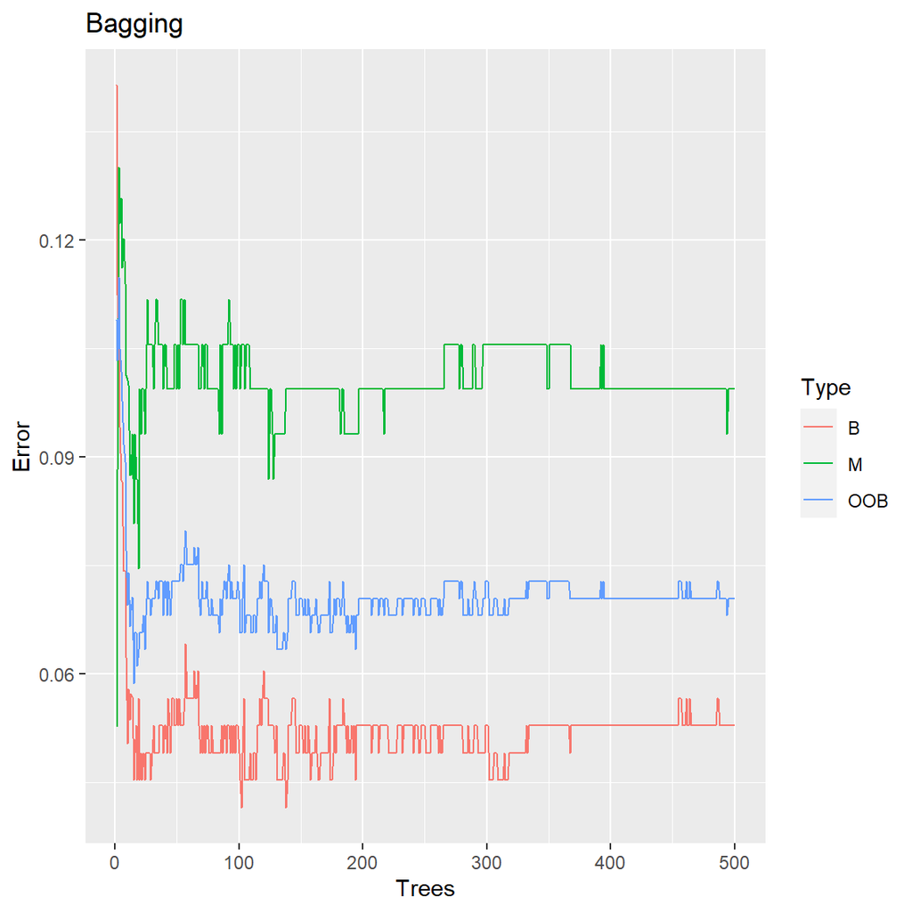

**325’den sonra error degerleri cok fazla degisim gostermiyor. Sample=325 alarak yeni bir model kuralim.**

## 325 Bootstrap Sample

```r
set.seed(101)
     Bagging.model1=randomForest(diagnosis~., data=train, mtry=9, ntree=325, importance=TRUE)
     Bagging.model1
```

```
##
     ## Call:
     ##  randomForest(formula = diagnosis ~ ., data = train, mtry = 9,      ntree = 325, importance = TRUE)
     ##                Type of random forest: classification
     ##                      Number of trees: 325
     ## No. of variables tried at each split: 9
     ##
     ##         OOB estimate of  error rate: 7.04%
     ## Confusion matrix:
     ##     B   M class.error
     ## B 252  13   0.0490566
     ## M  17 144   0.1055901
```

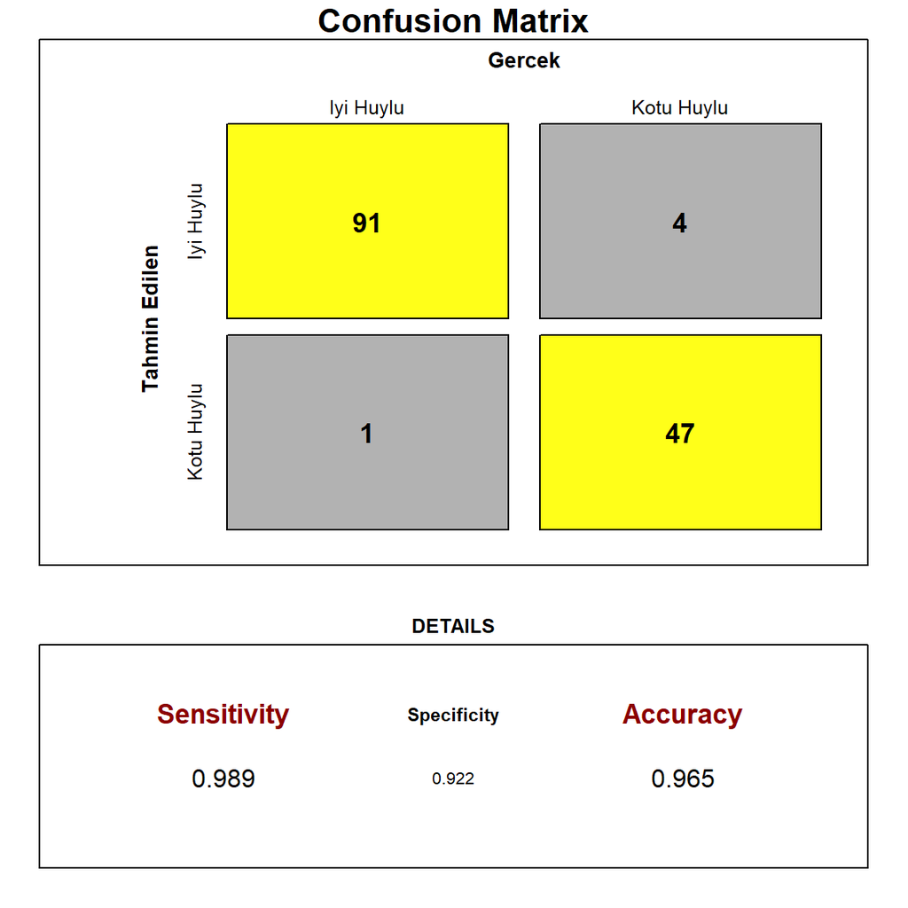

- **500 Bootstrap Sample ile tamamen ayni sonucu elde ettik. Tablo ile gorelim.**

## KARSILASTIRMA

| MODEL | ACCURACY ORANI | SENSITIVITY |
| --- | --- | --- |
| 500 Bootstrap Sample | 0.965 | 0.989 |
| 325 Bootstrap Sample | 0.965 | 0.989 |

**Tamamen ayni sonucu elde ettigimiz icin iki yontemi de kullanabiliriz. Tabii ki is yukunu hafifletmek icin az sample ile calismak daha mantikli olacaktir.**

# RANDOM FOREST

```r
set.seed(101)
     Randomforest.model1=randomForest(diagnosis~., data=train, mtry=3, importance=TRUE)
     Randomforest.model1
```

```
##
     ## Call:
     ##  randomForest(formula = diagnosis ~ ., data = train, mtry = 3,      importance = TRUE)
     ##                Type of random forest: classification
     ##                      Number of trees: 500
     ## No. of variables tried at each split: 3
     ##
     ##         OOB estimate of  error rate: 6.34%
     ## Confusion matrix:
     ##     B   M class.error
     ## B 254  11  0.04150943
     ## M  16 145  0.09937888
```

**Asagidaki grafikte degiskenkenlerin onemlilik derecelerine bakmis olduk. Concave point tekrardan en onemli degisken olarak gozukuyor.**

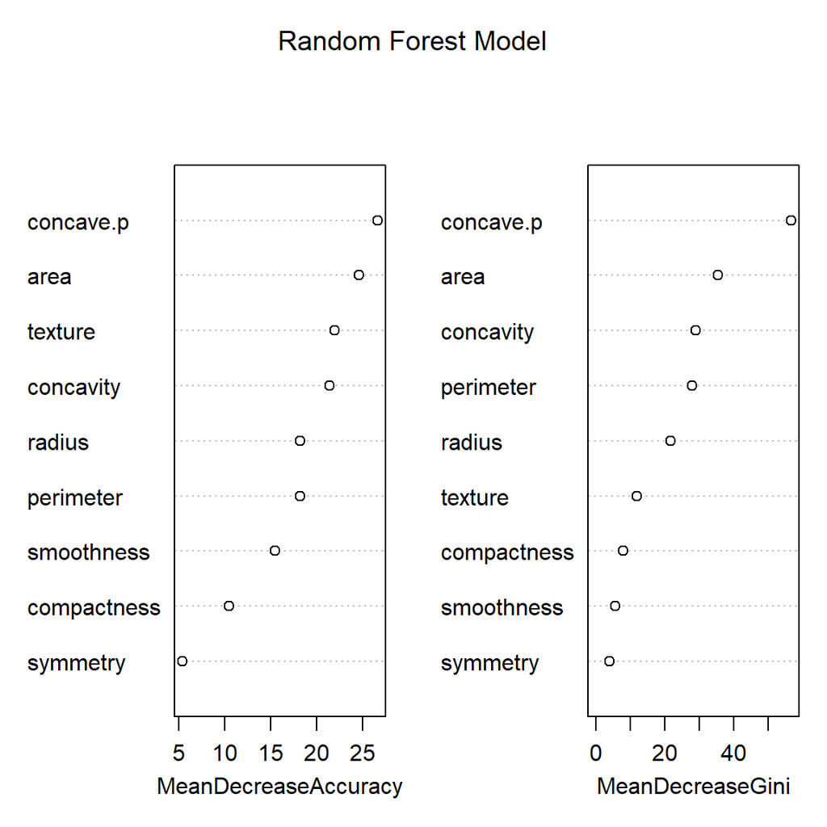

**Bu modelin performansini inceleyelim;**

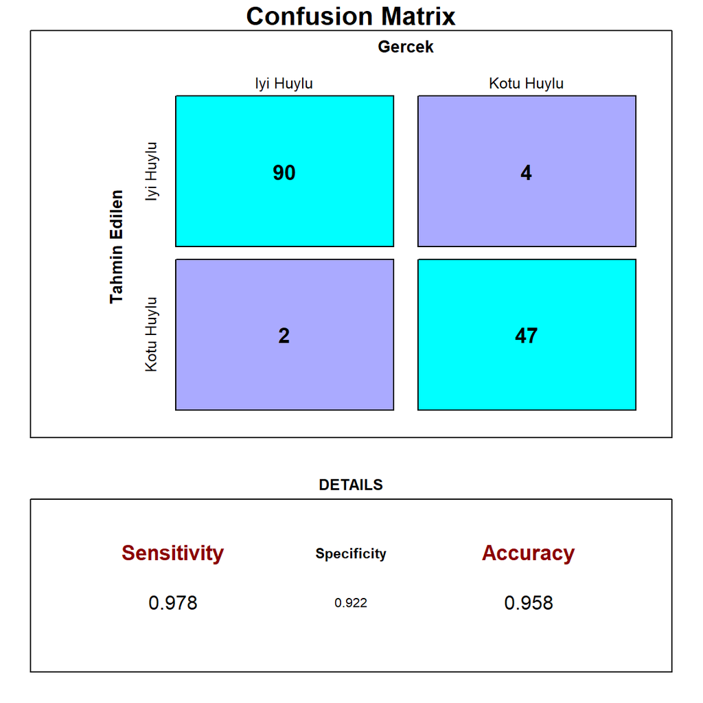

- **Random Forest en sık kullanilan yontemlerden biri oldugu icin accuracy oraninin digerlerine gore yuksek cikacagini dusunmustum. Ancak %95.8’lik bir gerileme yasadik.**

# BOOSTING

**Boosting; Bagging ve random foresta benzer ancak daha yavas ogrenir overfitting olmaz. Bir önceki adimini gelistirmeye yoneliktir.**

- **Boosting modelinizi olusturalim.**

```r
train$diagnosis=ifelse(train$diagnosis=="B",1,0)
     train$diagnosis=factor(train$diagnosis)

     test$diagnosis=ifelse(test$diagnosis=="B",1,0)
     test$diagnosis=factor(test$diagnosis)

     set.seed(101)
     boosting.model1=gbm((unclass(diagnosis)-1) ~ ., data=train,
                         distribution="bernoulli",
                         n.trees=5000,
                         interaction.depth=3,
                         verbose = F)
     summary(boosting.model1)
```

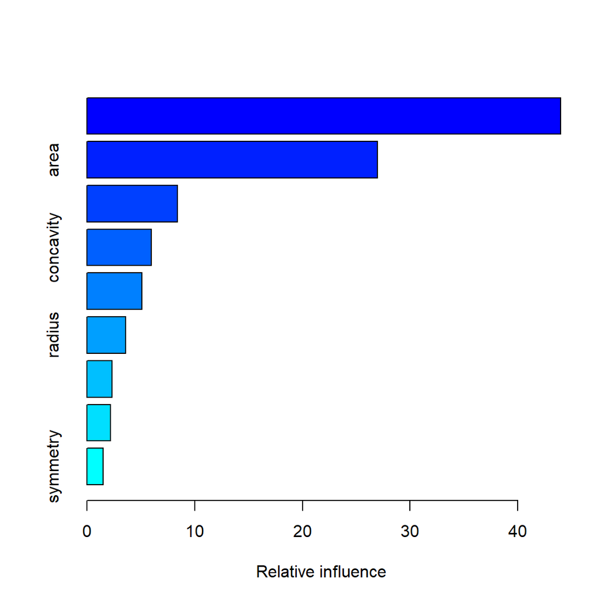

```
##                     var   rel.inf
     ## concave.p     concave.p 43.970743
     ## area               area 26.990354
     ## texture         texture  8.407096
     ## concavity     concavity  5.967026
     ## perimeter     perimeter  5.087588
     ## radius           radius  3.584628
     ## smoothness   smoothness  2.324411
     ## compactness compactness  2.171442
     ## symmetry       symmetry  1.496713
```

- **Daha once grafiklerde gordugumuz gibi concave point bu model icin acik ara en onemli degiskendir. Sonrasinda gelen area degiskenin de onemlilik derecesi oldukca yuksektir.**

**Modelin performansina bakalim.**

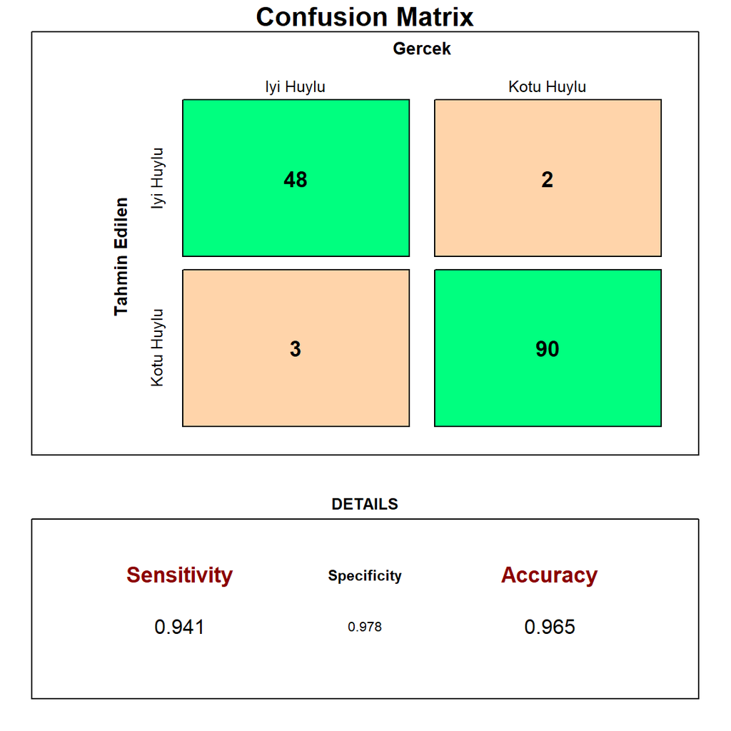

- **Yeniden %96.5 accuracy degerini elde ettik. Diger modellere gore sensitivity degerinde dusukluk var.**

# LOGISTIC REGRESSION

**Normal regresyonun kategorik veriler icin uyarlanmis halidir.**

**Train ve test datasi boosting yaparken 1 ve 0 olarak atandigi icin modeli kurmaya haziriz.**

```r
lojistik.model <- glm(diagnosis~ ., data=train, family=binomial)
     summary(lojistik.model)
```

```
##
     ## Call:
     ## glm(formula = diagnosis ~ ., family = binomial, data = train)
     ##
     ## Deviance Residuals:
     ##      Min        1Q    Median        3Q       Max
     ## -2.86279  -0.00188   0.04370   0.15413   1.81888
     ##
     ## Coefficients:
     ##              Estimate Std. Error z value Pr(>|z|)
     ## (Intercept)   3.57237   11.92855   0.299  0.76457
     ## radius        5.45404    4.11702   1.325  0.18525
     ## texture      -0.38697    0.07745  -4.997 5.84e-07 ***
     ## perimeter    -0.30528    0.55843  -0.547  0.58461
     ## area         -0.05259    0.01944  -2.705  0.00683 **
     ## smoothness  -76.31367   34.86612  -2.189  0.02861 *
     ## compactness  15.45907   17.08519   0.905  0.36556
     ## concavity    -6.72828    8.91995  -0.754  0.45067
     ## concave.p   -61.82899   32.60757  -1.896  0.05794 .
     ## symmetry    -12.34140   12.57496  -0.981  0.32638
     ## ---
     ## Signif. codes:  0 '***' 0.001 '**' 0.01 '*' 0.05 '.' 0.1 ' ' 1
     ##
     ## (Dispersion parameter for binomial family taken to be 1)
     ##
     ##     Null deviance: 564.91  on 425  degrees of freedom
     ## Residual deviance: 107.93  on 416  degrees of freedom
     ## AIC: 127.93
     ##
     ## Number of Fisher Scoring iterations: 9
```

**Regresyon modelimizi kurduk. Ancak daha once baktigimiz grafiklerde concave point degiskeninin en etkili degisken oldugu cikmisti. Burada ise bir tuhaflik var gibi gozukuyor. Coklu baglanti problemine baktigimiz zaman gorecegiz. Simdi train uzerinde ki tahmin performanslarina bakalim.**

```r
set.seed(101)
     predictions<-predict(lojistik.model,type="response")
     predtrain=ifelse(predictions>0.5,1,0)
```

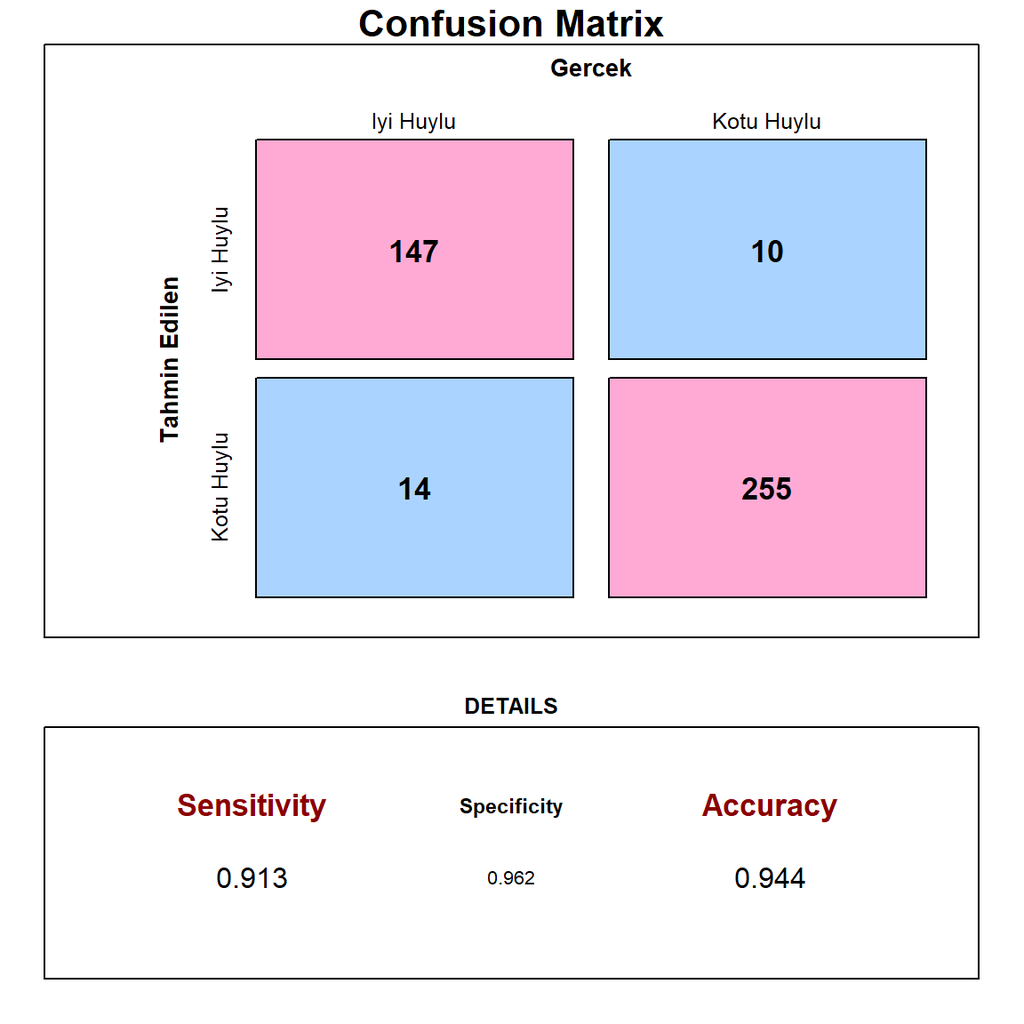

- **%94.4 dogruluk oranina sahibiz. Simdi test uzerinde bakalim.**

```r
set.seed(101)
     predicted=predict(lojistik.model,test,type="response")
     predtest=ifelse(predicted>0.5,1,0)
```

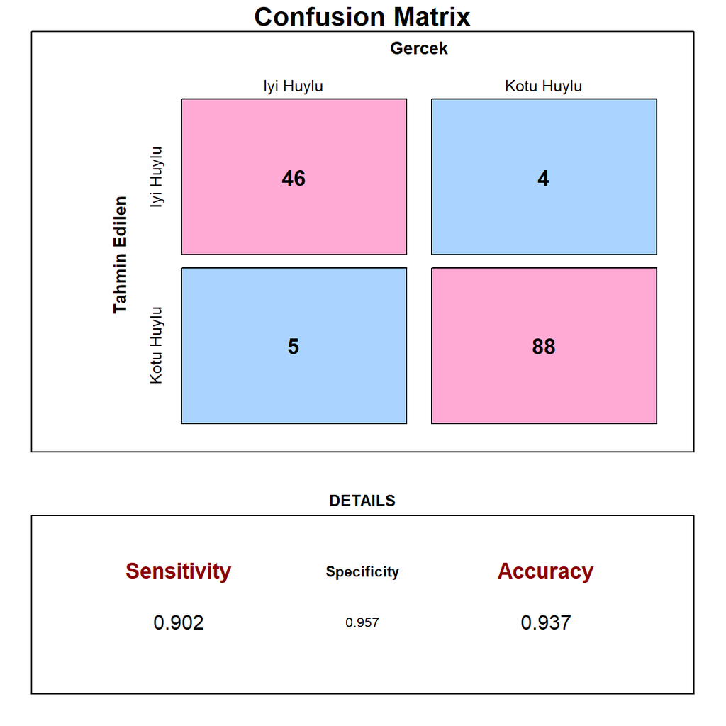

- **Test uzerinde accuracy degerimiz %93.7 cikmistir. Yeniden gayet yuksek bir deger elde ettik.**

**Accuracy degerimiz dusuk ciksaydi bakmamiz gereken bazi yontemler olacakti. Bunlar;**

- *Cutoff degerinin uygun secilmemesi*
- *Multicollinearity*
- *Degiskenlerin, bagimli degiskeni aciklamakta yetersiz kalmasi*

## Optimum Cutoff

**Asagidaki grafige bakilarak amacimiza gore cuttoff degeri belirlenebilir. İki egrinin kesim noktasi olacak sekilde.**

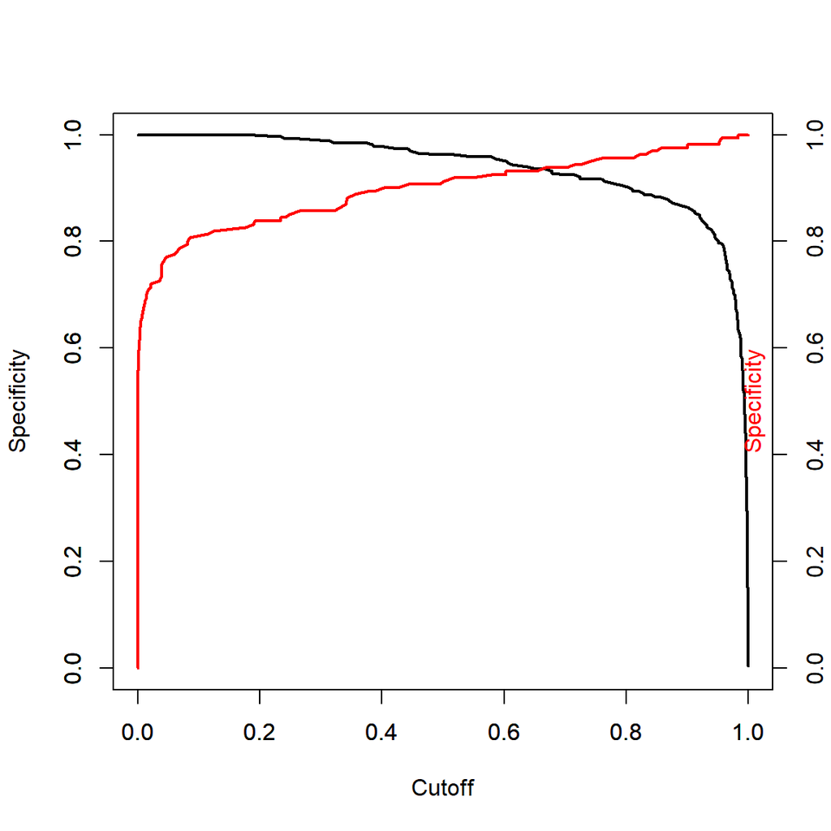

## Receiver Operating Characteristic Curve (ROC)

**AUC degeri egri altinda kalan alani ifade eder buyuk olmasi (alan ne kadar buyukse model o kadar iyi) bizim icin iyi bir durumdur.**

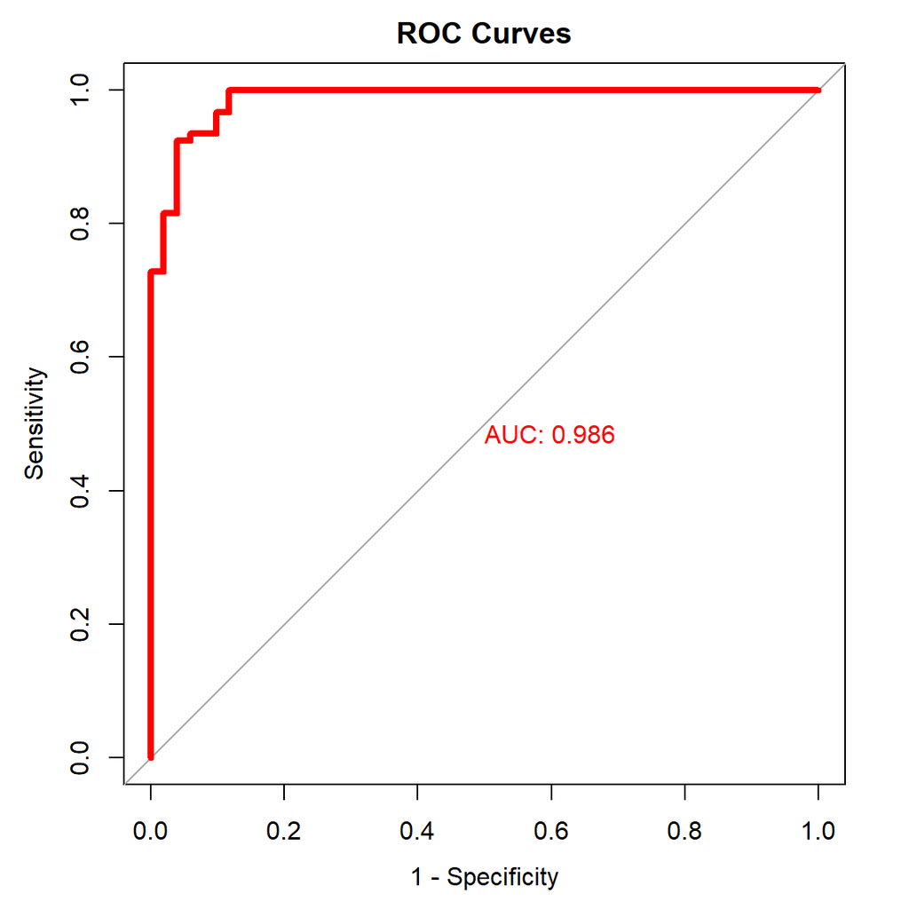

**Egri altinda kalan 0.986 bulunmustur. Modelimizin gayet iyi oldugunu gosteriyor.**

## Multicollinearity

```r
vif(lojistik.model)
```

```
##      radius     texture   perimeter        area  smoothness compactness
     ##  863.433976    1.595421  665.014790  129.127930    4.164181    8.678271
     ##   concavity   concave.p    symmetry
     ##    4.217500    5.722260    1.964350
```

**Goruldugu uzere bir cok degisken cok yuksek degerler almis. Vif>10 ise coklu baglanti probleminden soz edebiliriz. Bu degiskenler modeli kotu etkileyebildigi icin modelden cikarip tekrar kurdugumuzda nasil bir degisim olacagina bakalim.**

```r
lojistik.model <- glm(diagnosis~texture+smoothness+compactness+concavity+concave.p+symmetry, data=train, family=binomial)
     summary(lojistik.model)
```

```
##
     ## Call:
     ## glm(formula = diagnosis ~ texture + smoothness + compactness +
     ##     concavity + concave.p + symmetry, family = binomial, data = train)
     ##
     ## Deviance Residuals:
     ##      Min        1Q    Median        3Q       Max
     ## -2.51389  -0.05794   0.07734   0.21085   2.27705
     ##
     ## Coefficients:
     ##               Estimate Std. Error z value Pr(>|z|)
     ## (Intercept)   10.49715    2.89243   3.629 0.000284 ***
     ## texture       -0.33408    0.06261  -5.336 9.52e-08 ***
     ## smoothness    24.56348   24.48692   1.003 0.315800
     ## compactness   19.77807    9.54851   2.071 0.038328 *
     ## concavity      1.21354    6.79643   0.179 0.858286
     ## concave.p   -152.17955   21.66142  -7.025 2.13e-12 ***
     ## symmetry      -2.24258   10.68006  -0.210 0.833685
     ## ---
     ## Signif. codes:  0 '***' 0.001 '**' 0.01 '*' 0.05 '.' 0.1 ' ' 1
     ##
     ## (Dispersion parameter for binomial family taken to be 1)
     ##
     ##     Null deviance: 564.91  on 425  degrees of freedom
     ## Residual deviance: 142.25  on 419  degrees of freedom
     ## AIC: 156.25
     ##
     ## Number of Fisher Scoring iterations: 7
```

**Concave point degiskeninin anlamliligi cok fazla artti. Vif degeri yuksek olan degiskenleri cikarmak ise yaramis gibi gozukuyor. Accuracy degerimizde degisiklik olup olmadigina bakalim.**

```r
set.seed(101)
     predicted=predict(lojistik.model,test,type="response")
     predtest=ifelse(predicted>0.5,1,0)
```

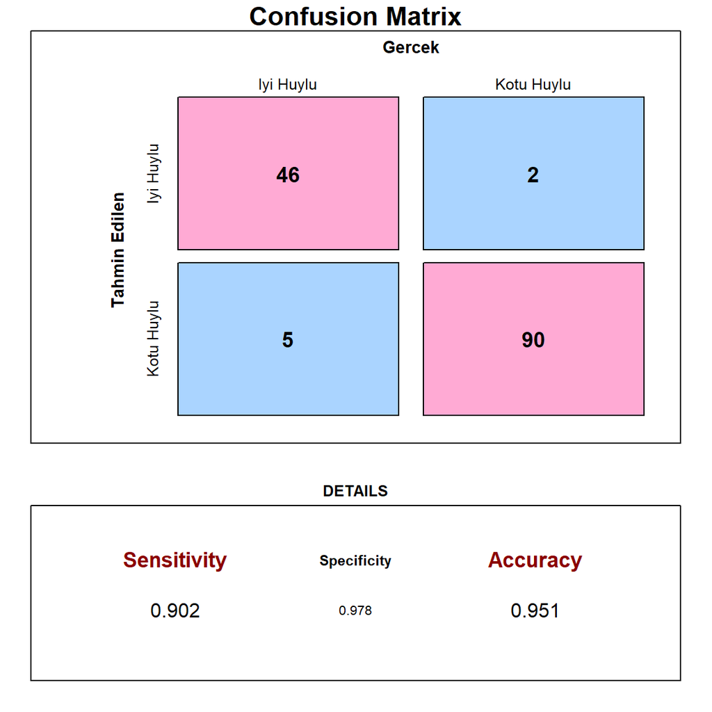

**%93.7 olan dogruluk oranimiz %95.1’e cikmis oldu.**

```r
vif(lojistik.model)
```

```
##     texture  smoothness compactness   concavity   concave.p    symmetry
     ##    1.324888    2.038292    3.424839    3.116804    3.485161    1.687981
```

**Ayrica modelin coklu baglanti problemi kalkmis oldu.**

# EN IYI MODEL

**Buraya kadar kullandigimiz butun yontemlerin accuracy ve sensitivity degerlerine bakarak en iyi modeli secelim.**

- *Accuracy: Dogruluk orani*
- *Sensitivite: Tahmin pozitif iken gercekte pozitif olma olasiligi*

| MODEL | ACCURACY ORANI | SENSITIVITY |
| --- | --- | --- |
| Puning Decision Trees | 0.965 | 0.978 |
| 325 Bootstrap Sample | 0.965 | 0.989 |
| Random Forest | 0.958 | 0.978 |
| Boosting | 0.965 | 0.941 |
| Logistic Regression | 0.951 | 0.902 |

**Tabloya baktigimiz zaman bir cok modelde en yuksek accuracy oranina sahibiz. Ancak bagging yonteminde en yuksek sensitivity degerine sahip oldugumuz icin BAGGING kullanmak mantikli olacaktir.**

# 2. REGRESSION TREE

[figure not shown]

```r
satis=read.csv("C:/Users/Tarık/Desktop/advertising.csv")
```

**Farkli tur reklamlarin satislar uzerinde ki etkisi aristirilmak isteniyor.**

- *TV: Televizyon reklamlari*
- *Radio: Radyo reklamlari*
- *Newspaper: Gazete reklamlari*
- *Sales: Satislar*

*Kaynak: https://www.kaggle.com/ashydv/advertising-dataset*

```r
head(satis)
```

```
##      TV Radio Newspaper Sales
     ## 1 230.1  37.8      69.2  22.1
     ## 2  44.5  39.3      45.1  10.4
     ## 3  17.2  45.9      69.3  12.0
     ## 4 151.5  41.3      58.5  16.5
     ## 5 180.8  10.8      58.4  17.9
     ## 6   8.7  48.9      75.0   7.2
```

**Train ve test verisini ayiralim.**

```r
set.seed(101)
     train=sample(1:nrow(satis),140)
     test=satis[-train,"Sales"]
```

# BAGGING

```r
set.seed(101)
     bag.satis=randomForest(Sales~.,data=satis,subset=train,mtry=3,importance=TRUE)
     bag.satis
```

```
##
     ## Call:
     ##  randomForest(formula = Sales ~ ., data = satis, mtry = 3, importance = TRUE,      subset = train)
     ##                Type of random forest: regression
     ##                      Number of trees: 500
     ## No. of variables tried at each split: 3
     ##
     ##           Mean of squared residuals: 1.752577
     ##                     % Var explained: 93.46
```

**500 agac ve 3 degisken ile bagging modelimizi kurduk. Artiklarin kareler ortalamasini (MSE) ve % kac varyansin aciklandigini gorebiliyoruz. %93.46 iyi duruyor. Grafik ile bakalim.**

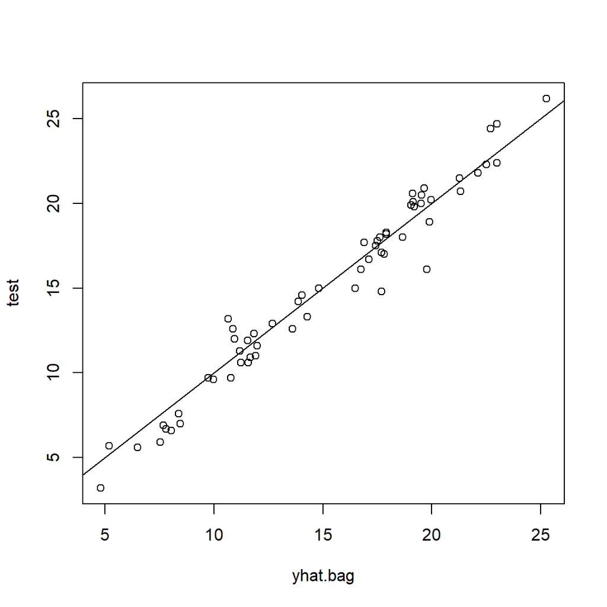

```r
yhat.bag = predict(bag.satis,newdata=satis[-train,])
     plot(yhat.bag, test)
     abline(0,1)
```

**Y sapkalar ile test sacilim grafigine baktigimiz zaman tahmin performansinin gayet iyi durdugunu gorebiliyoruz.**

```r
mean((yhat.bag-test)^2)
```

```
## [1] 1.222585
```

**Yukarida ki hesaplama ile MSE skoruna ulasmis olduk. Bu deger ne kadar az ise modelimiz o kadar iyi demektir.**

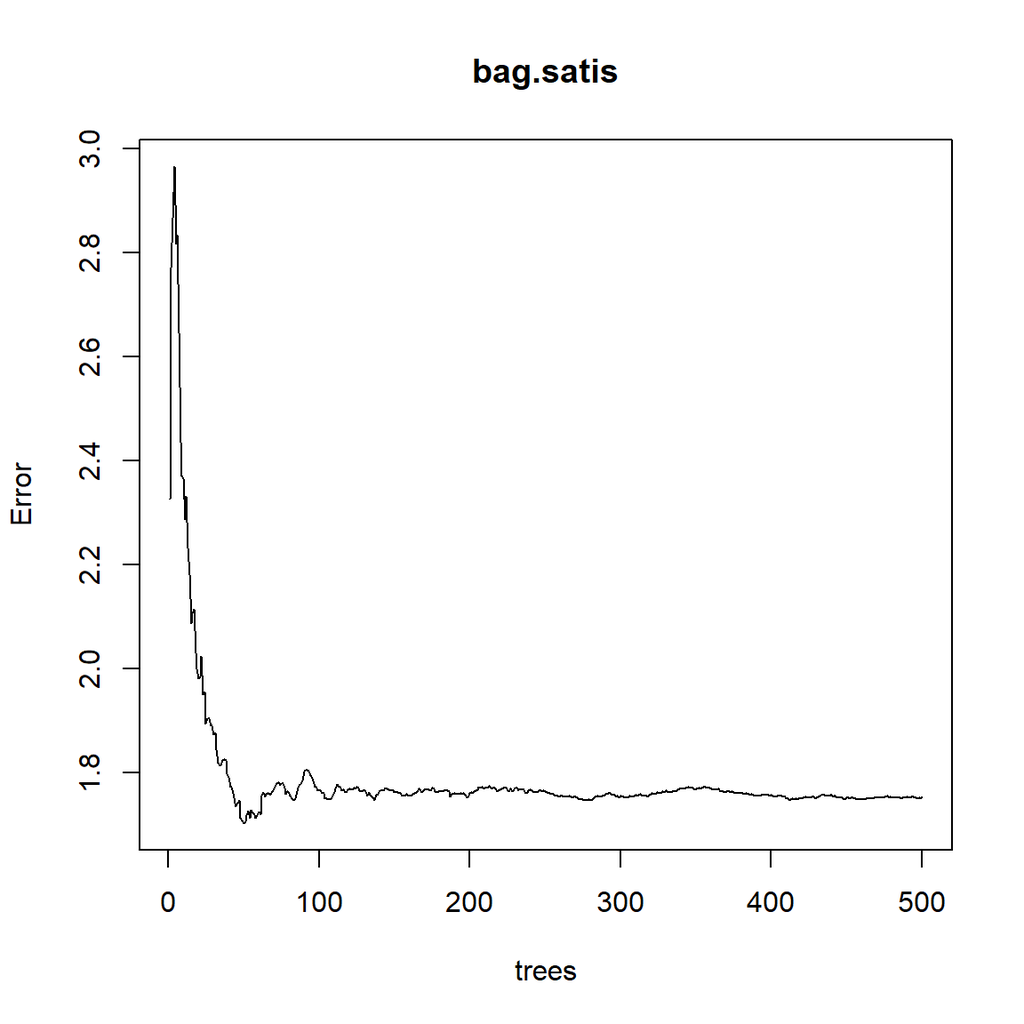

```r
plot(bag.satis)
```

**Bu grafige baktigimizda ise modeli 500 agac ile kurmaya gerek olmadigini goruyoruz. 100’den sonra cok az degisim yasanmis ve 50’de hata degeri oldukca azalmis. 50 agac kullanarak modeli tekrar kuralim.**

```r
bag.satis=randomForest(Sales~.,data=satis,subset=train,mtry=3,ntree=50)
     yhat.bag = predict(bag.satis,newdata=satis[-train,])
     mean((yhat.bag-test)^2)
```

```
## [1] 1.239579
```

**Goruldugu uzere 0.01’lik bir hata yukselmesi oldu ancak bu deger cok dusuk oldugu icin is yukunu azaltmak amaciyla 500 agac yerine 50 agacli modeli kullanmak gayet mantikli bir secim olacaktir.**

# RANDOM FOREST

**Random forest Bagging yonteminin mtry=√p sekli oldugu icin mtry=2 alarak ayni islemleri tekrarlayacagiz.**

```r
set.seed(101)
     rf.satis=randomForest(Sales~.,data=satis,subset=train,mtry=2,importance=TRUE)
     yhat.rf = predict(rf.satis,newdata=satis[-train,])
     mean((yhat.rf-test)^2)
```

```
## [1] 1.44166
```

**Test verisi uzerinde hesaplanan MSE degeri artmis. Verimizde az degisken oldugu icin daha iyi bir sonuc elde edememis olabiliriz.**

**Simdi farkli mtray degerleri icin Out of bag-MSE degerleri ile Test-MSE degerlerini karsilastiralim.**

```r
oob.err<-double(3)
     test.err<-double(3)

     for(mtry in 1:3)
     {
       rf=randomForest(Sales ~ . , data = satis , subset = train,mtry=mtry,ntree=500)
       oob.err[mtry] = rf$mse[500]
       pred<-predict(rf,satis[-train,])
       test.err[mtry]= with(satis[-train,], mean( (Sales - pred)^2))
       cat(mtry," ")

     }
```

```
## 1  2  3
```

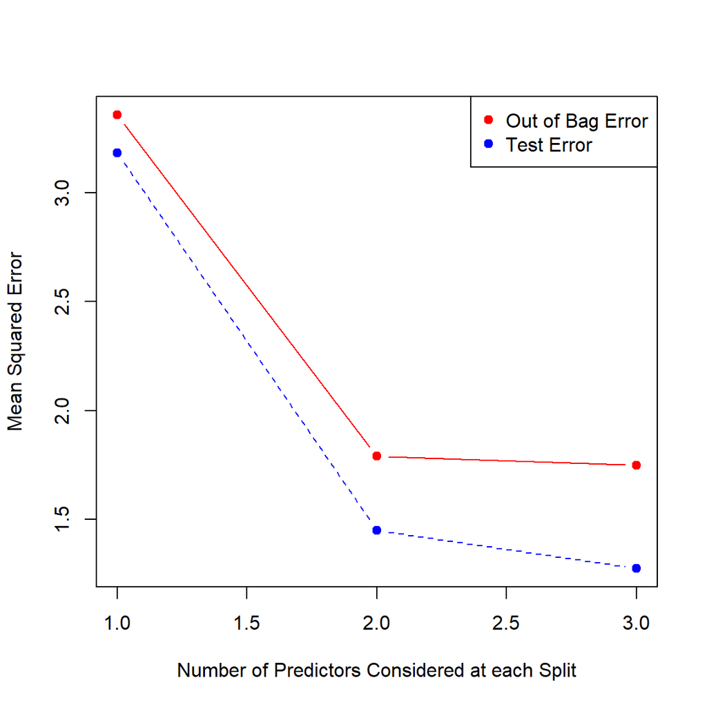

```r
matplot(1:mtry , cbind(oob.err,test.err), pch=19 , col=c("red","blue"),type="b",ylab="Mean Squared Error",xlab="Number of Predictors Considered at each Split")
     legend("topright",legend=c("Out of Bag Error","Test Error"),pch=19, col=c("red","blue"))
```

**3 icin en dusuk error degerini alacagiz gibi duruyor. Bakalim.**

```r
test.err[3]
```

```
## [1] 1.275808
```

**Goruldugu uzere error degerimiz dusmustur.**

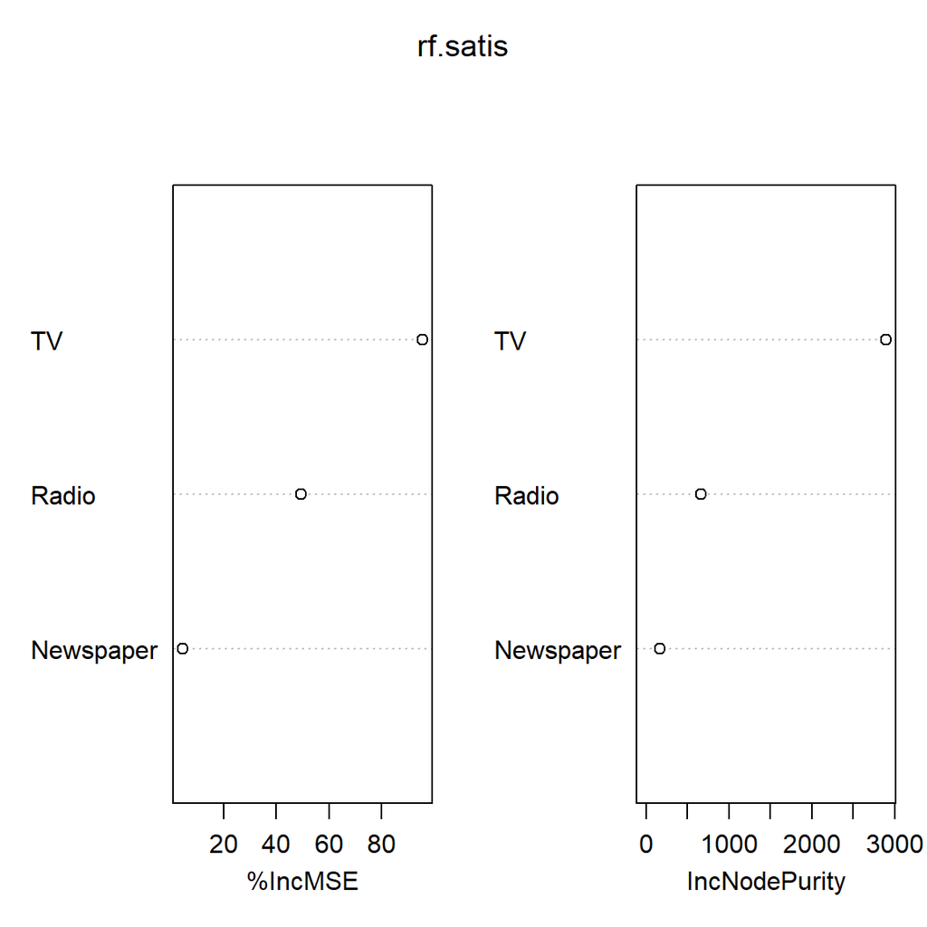

```r
varImpPlot(rf.satis)
```

**Degiskenlerin onemlilik derecesine baktigimiz bu grafik en etkili degiskenin TV oldugunu gostermis oluyor.**

**Korelasyon ile de bakabiliriz.**

```r
cor(satis$TV,satis$Sales)
```

```
## [1] 0.9012079
```

```r
cor(satis$Radio,satis$Sales)
```

```
## [1] 0.3496311
```

```r
cor(satis$Newspaper,satis$Sales)
```

```
## [1] 0.15796
```

- *TV-Satis: %90 pozitif iliski*
- *Radyo-Satis: %35 pozitif iliski*
- *Gazete-Satis: %15 pozitif iliski*

# BOOSTING

**5000 agac ve gaussian dagilimi ile modelimizi kuralim.**

```r
set.seed(101)
     boost.satis=gbm(Sales~.,data=satis[train,],distribution="gaussian",n.trees=5000,interaction.depth=4)
     summary(boost.satis)
```

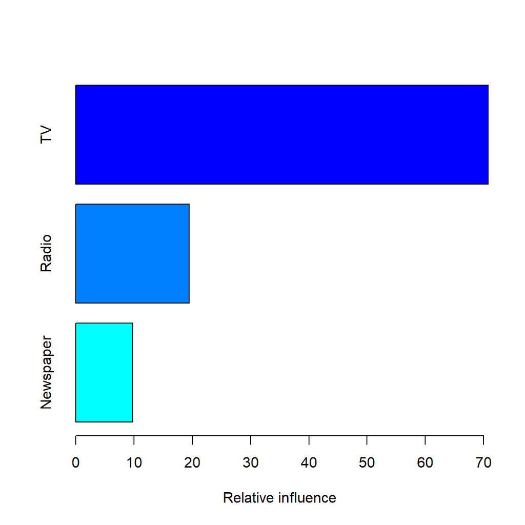

```
##                 var   rel.inf
     ## TV               TV 70.760012
     ## Radio         Radio 19.479845
     ## Newspaper Newspaper  9.760143
```

**Random forest ile gordugumuz gibi degiskenlerin onem sirasi tekrar verildi.**

**Modelin test verisi uzerindeki performansini inceleyelim;**

```r
yhat.boost=predict(boost.satis,newdata=satis[-train,],n.trees=5000)
     mean((yhat.boost-test)^2)
```

```
## [1] 1.967786
```

**MSE degerimizi elde etmis olduk. Karsilastirma icin kullanacagiz.**

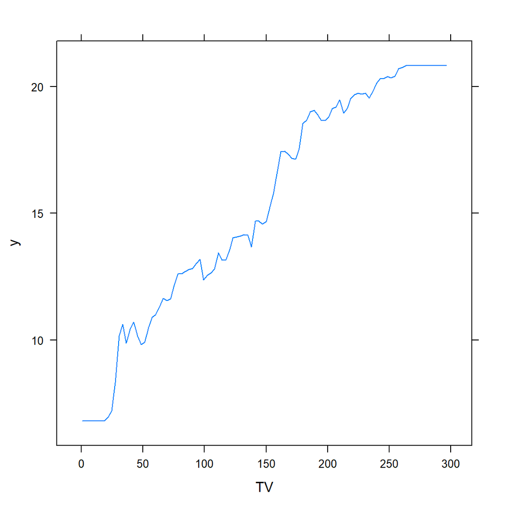

```r
plot(boost.satis,i="TV")
```

**En anlamli degiskenin etkisini grafik ile gorebiliyoruz.**

- **Peki eger 5000 agac yerine baska bir deger secseydik ne olurdu? Bunu arastirmak icin modeli tekrar kuracagim.**

```r
satis.boost=gbm(Sales ~ . ,data = train, distribution = "gaussian",n.trees = 10000,
                       shrinkage = 0.01, interaction.depth = 4)
     satis.boost
```

```
## gbm(formula = Sales ~ ., distribution = "gaussian", data = train,
     ##     n.trees = 10000, interaction.depth = 4, shrinkage = 0.01)
     ## A gradient boosted model with gaussian loss function.
     ## 10000 iterations were performed.
     ## There were 3 predictors of which 3 had non-zero influence.
```

**10,000 agac ile modeli tekrar kurduk. Simdi error degerlerinin nasil degistigine her 100 degerde bir bakacagiz ve optimum agac sayisini sececegiz.**

```r
n.trees = seq(from=100 ,to=10000, by=100)
     predmatrix<-predict(satis.boost,train,n.trees = n.trees)
     test.error<-with(train,apply( (predmatrix-Sales)^2,2,mean))
     test.error
```

```
##        100        200        300        400        500        600        700
     ## 6.14456654 2.47134715 1.59730007 1.27471203 1.12313840 1.01292242 0.92499844
     ##        800        900       1000       1100       1200       1300       1400
     ## 0.85755041 0.79885726 0.74335108 0.69352523 0.65080147 0.61206054 0.58099635
     ##       1500       1600       1700       1800       1900       2000       2100
     ## 0.54857711 0.51911559 0.49206272 0.46974546 0.44917187 0.42668142 0.40839265
     ##       2200       2300       2400       2500       2600       2700       2800
     ## 0.38966438 0.37330542 0.35839057 0.34530275 0.33160597 0.31890269 0.30472918
     ##       2900       3000       3100       3200       3300       3400       3500
     ## 0.29319601 0.28192100 0.27243725 0.26239740 0.25397309 0.24578162 0.23738580
     ##       3600       3700       3800       3900       4000       4100       4200
     ## 0.23057075 0.22375427 0.21800815 0.21205860 0.20653354 0.20118443 0.19617320
     ##       4300       4400       4500       4600       4700       4800       4900
     ## 0.19077499 0.18603906 0.18125527 0.17696474 0.17317608 0.16952789 0.16605922
     ##       5000       5100       5200       5300       5400       5500       5600
     ## 0.16316914 0.15998796 0.15689098 0.15373510 0.15065537 0.14792825 0.14508619
     ##       5700       5800       5900       6000       6100       6200       6300
     ## 0.14252742 0.13982980 0.13770373 0.13557080 0.13361952 0.13146627 0.12932211
     ##       6400       6500       6600       6700       6800       6900       7000
     ## 0.12753214 0.12599122 0.12434549 0.12283882 0.12107648 0.11970968 0.11835645
     ##       7100       7200       7300       7400       7500       7600       7700
     ## 0.11715639 0.11568419 0.11441189 0.11317550 0.11208270 0.11085822 0.10995099
     ##       7800       7900       8000       8100       8200       8300       8400
     ## 0.10892054 0.10803975 0.10711854 0.10622006 0.10528961 0.10453762 0.10364210
     ##       8500       8600       8700       8800       8900       9000       9100
     ## 0.10283302 0.10206034 0.10128950 0.10059591 0.09990432 0.09932256 0.09872194
     ##       9200       9300       9400       9500       9600       9700       9800
     ## 0.09810107 0.09743104 0.09683261 0.09623858 0.09575007 0.09524778 0.09480498
     ##       9900      10000
     ## 0.09433457 0.09380587
```

**Goruldugu uzere 10,000’e kadar surekli bir dusus var ancak 5000’den sonra bu dusus oldukca zayifliyor. Grafik ile daha rahat bir gozlem yaparak son kararimizi verelim.**

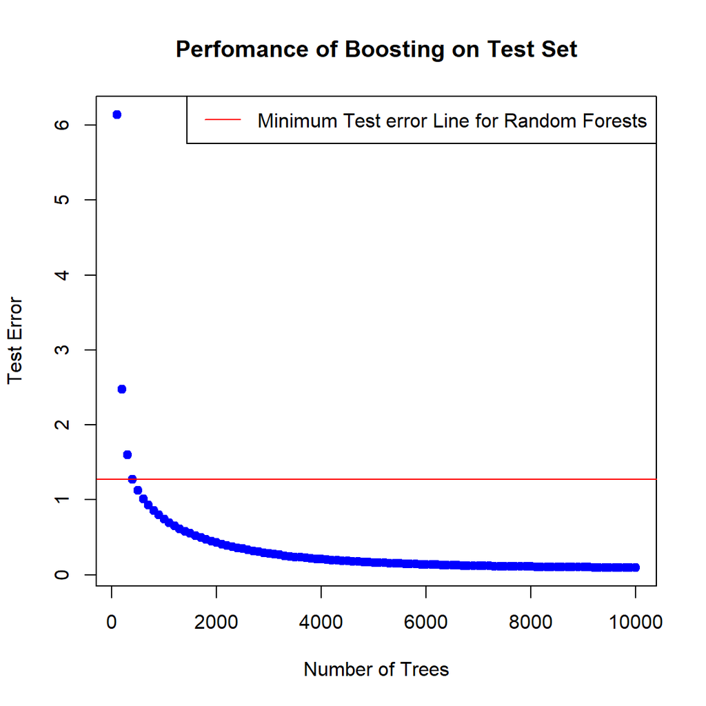

```r
plot(n.trees , test.error , pch=19,col="blue",xlab="Number of Trees",ylab="Test Error", main = "Perfomance of Boosting on Test Set")
     abline(h = min(test.err),col="red")
     legend("topright",c("Minimum Test error Line for Random Forests"),col="red",lty=1,lwd=1)
```

**Grafige de baktigimizda goruyoruz ki ilk kullandigimiz 5000 degeri gayet mantikli duruyor. Tabi ki en dusuk error degeri icin 10,000 alabiliriz ancak overfittingden kacinmamiz gerekiyor.**

# EN IYI MODEL

| MODEL | HATA KARELER ORTALAMASI |
| --- | --- |
| Bagging (500 Sample) | 1.22258 |
| Bagging (50 Sample) | 1.23957 |
| Random Forest | 1.44166 |
| Boosting | 1.96778 |

- **En dusuk MSE degeri bizim icin en iyi model olacaktir. Tabloya gore 500 sample ile olusturulan bagging en iyi model gozukuyor. Ancak 50 sample ile aralarinda cok az fark oldugu icin, is yukunden kacinmak icin o da secilebilir.**

# 3. KUMELEME ANALIZI

[figure not shown]

```r
cars <- read_excel("C:/Users/Tarık/Desktop/car_consumption.xls")
```

- **Kaynak:** http://data-mining-tutorials.blogspot.com/2010/05/solutions-for-multicollinearity-in.html
- **Aciklama:** Farkli model arabalarin ozellikleri verilmistir.

**Bagimli Degisken :**

- **Price:** Arabanin fiyati

**Aciklayici Degiskenler:**

- **Cylinder:** Arabanin silindir hacmi
- **Power:** Arabanin gucu (beygiri)
- **Weight:** Arabanin agirligi
- **Consumption:** Yakit tuketimi
- **Gozlem Sayisi:** 27
- **Aciklayici Degisken Sayisi:** 4

```r
cars=cars[,-1]
     summary(cars)
```

```
##      Price          Cylinder        Power            Weight
     ##  Min.   :10450   Min.   : 658   Min.   : 29.00   Min.   : 650.0
     ##  1st Qu.:19615   1st Qu.:1360   1st Qu.: 54.50   1st Qu.: 982.5
     ##  Median :25000   Median :1983   Median : 85.00   Median :1140.0
     ##  Mean   :28261   Mean   :1802   Mean   : 78.15   Mean   :1193.1
     ##  3rd Qu.:36775   3rd Qu.:2300   3rd Qu.: 99.00   3rd Qu.:1450.0
     ##  Max.   :50900   Max.   :2972   Max.   :150.00   Max.   :1800.0
     ##   Consumption
     ##  Min.   : 5.70
     ##  1st Qu.: 6.95
     ##  Median : 9.20
     ##  Mean   : 9.13
     ##  3rd Qu.:11.05
     ##  Max.   :12.80
```

**Anlamli farkliliklar var. Scale komutu ile olcekleyelim.**

```r
df=scale(cars)
     head(df)
```

```
##           Price   Cylinder     Power     Weight Consumption
     ## [1,] -1.3220490 -1.5070037 -1.407470 -1.7286382   -1.520063
     ## [2,] -1.2514257 -1.2752962 -1.193977 -1.2830704   -1.475742
     ## [3,] -1.4133039 -1.4234629 -1.498967 -1.4740280   -1.342777
     ## [4,] -0.8824387 -0.6495283 -1.041483 -0.7579368   -1.165491
     ## [5,] -1.0661387 -0.9568954 -1.376971 -0.9488945   -1.032527
     ## [6,] -1.1530292 -1.8033372 -1.407470 -1.4422017   -1.032527
```

# K-MEANS KUMELEME

**Oncelikle manuel bir sekilde bir k degeri verip sonuclara bakalim. Ben k=2 almayi tercih ettim.**

- *nstart: Coklu baslangic noktasi atamak icin kullaniliyor.*
- *centers: k tane merkez noktasi olusturmak icin kullaniliyor.*

```r
k2=kmeans(df, centers = 2, nstart = 25)
     str(k2)
```

```
## List of 9
     ##  $ cluster     : int [1:27] 2 2 2 2 2 2 2 2 2 1 ...
     ##  $ centers     : num [1:2, 1:5] 0.876 -0.814 0.845 -0.785 0.838 ...
     ##   ..- attr(*, "dimnames")=List of 2
     ##   .. ..$ : chr [1:2] "1" "2"
     ##   .. ..$ : chr [1:5] "Price" "Cylinder" "Power" "Weight" ...
     ##  $ totss       : num 130
     ##  $ withinss    : num [1:2] 21.8 17.9
     ##  $ tot.withinss: num 39.7
     ##  $ betweenss   : num 90.3
     ##  $ size        : int [1:2] 13 14
     ##  $ iter        : int 1
     ##  $ ifault      : int 0
     ##  - attr(*, "class")= chr "kmeans"
```

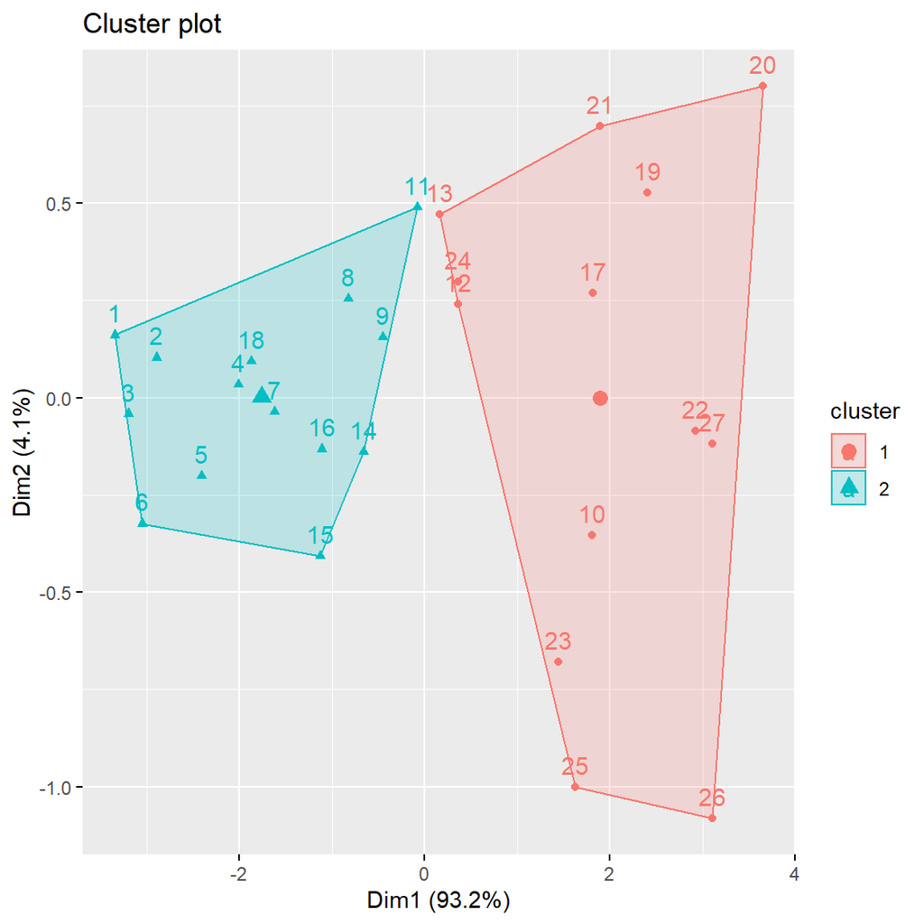

```r
fviz_cluster(k2, data = df)
```

**Goruldugu uzere k=2 icin bu sekilde bir kumeleme yapilmis oldu. Eger k degerini farkli atasaydik nasil olurdu bakalim.**

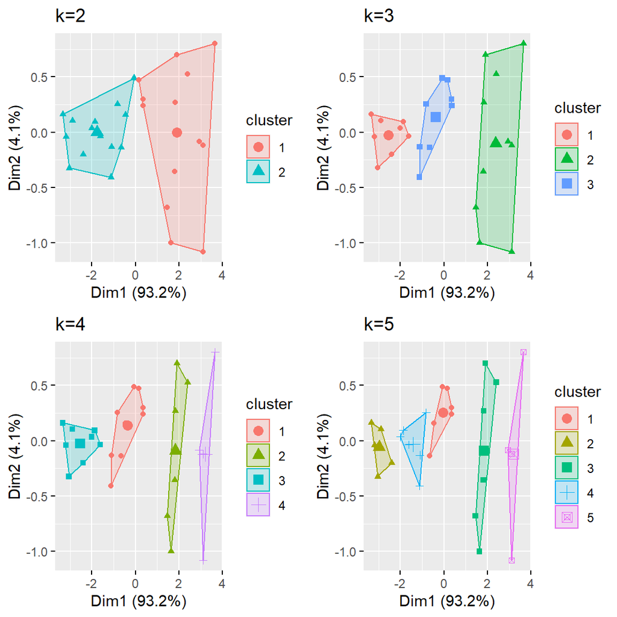

**3’den sonra olusan kumelerde bir bozukluk var gibi duruyor. En iyi k degerine ulasmamiz gerekiyor. Bunun icin Elbow ve Average Silhoutte yontemlerini kullanacagiz.**

## Elbow Yontemi

- *Kumeler ici hata hesaplama*

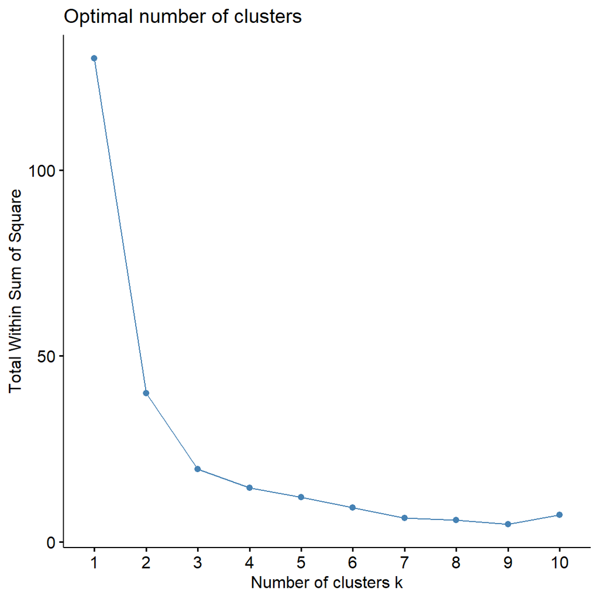

```r
set.seed(134)
     fviz_nbclust(df, kmeans, method = "wss")
```

- **En iyi k degeri 2 veya 3 gozukuyor cunku sonrasinda yasanan kirilmalar cok az. Diger yontemimize bakalim.**

## Average Silhoutte

- *Kume ici kalite skoru hesaplama*

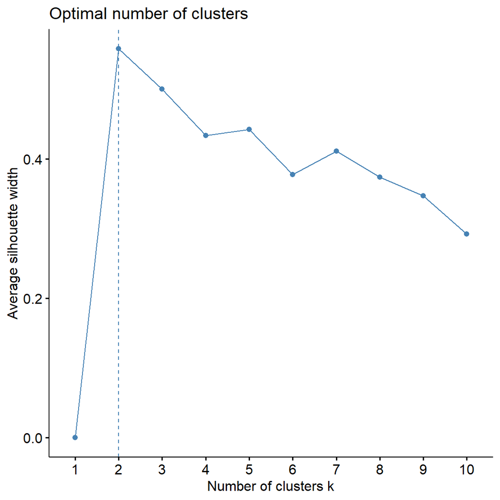

```r
fviz_nbclust(df, kmeans, method = "silhouette")
```

- **Burada ise optimum k=2 olarak belirlenmis. k=2 alarak devam etmek mantikli olacaktir.**

```r
set.seed(123)
     final <- kmeans(df, 2, nstart = 24)
     print(final)
```

```
## K-means clustering with 2 clusters of sizes 13, 14
     ##
     ## Cluster means:
     ##        Price   Cylinder      Power     Weight Consumption
     ## 1  0.8761245  0.8448700  0.8377218  0.8346010   0.8494321
     ## 2 -0.8135442 -0.7845221 -0.7778845 -0.7749866  -0.7887584
     ##
     ## Clustering vector:
     ##  [1] 2 2 2 2 2 2 2 2 2 1 2 1 1 2 2 2 1 2 1 1 1 1 1 1 1 1 1
     ##
     ## Within cluster sum of squares by cluster:
     ## [1] 21.76610 17.94489
     ##  (between_SS / total_SS =  69.5 %)
     ##
     ## Available components:
     ##
     ## [1] "cluster"      "centers"      "totss"        "withinss"     "tot.withinss"
     ## [6] "betweenss"    "size"         "iter"         "ifault"
```

- *2 kumeye ayirdigimiz bu sonucta kumelerin kac gozleme sahip oldugunu, kumelerin ortalamalarini, degiskenlerin hangi kumede oldugunu ve kumeler arasi hata kareler ortalamasini gorebiliyoruz.*

```r
cars %>%
       mutate(Cluster = final$cluster) %>%
       group_by(Cluster) %>%
       summarise_all("mean")
```

```
## # A tibble: 2 x 6
     ##   Cluster  Price Cylinder Power Weight Consumption
     ##     <int>  <dbl>    <dbl> <dbl>  <dbl>       <dbl>
     ## 1       1 39302.    2338. 106.   1455.       11.0
     ## 2       2 18008.    1304.  52.6   950.        7.35
```

- *Her bir kumeye gore gruplayip degiskenler bazinda ortalama deger elde ettik.*
- *Bu tablo ile kumelerin ortalamalarini gorebiliyoruz.*